# Course Project

Practical Machine Learning

Jason Torpy

# Main Body

## Executive Summary

In this project, we seek prediction for the variable classe in weight lifting data. We reviewed several models, settling on the Random Forest as the best predictor. We found nearly 100% Accuracy with less than 1% out of sample error. Cross-validation was included (K=5, though cv is technically inherent to Random Forest). These outcomes, while not perfect, were superior to the other models and sufficient for our prediction requirements without excessive computing complexity

*Grading note: Word count is well under 2000, even with code, and there are 4 figures in the body of the report (Accuracy, C results, final fit model with OOB, and a chart of importance). The Appendices are optional and have additional figures should you wish to review them.*

### Project Instructions

Predict outcomes (classe) using personal activity data. Data is from the Weight Lifting Dataset below, citations found there as well. http://groupware.les.inf.puc-rio.br/har

Describe out the model was built, cross-validation, expected out of sample error, and the reason behind choices. Predict 20 test cases.

Publish to github repo with Rmd and resulting HTML as gh-page, with under 2000 words with fewer than 5 figures.

## Load and Explore Data

Preview of the data shows a training set of 19622 observations of 160 variables, with 20 observations in the test set. We need to do initial exploration of NAs for proper import. NAs, including blank and div/0 are cleaned on loading. That yields a first finding that about 100 variables have all NAs. While some are filled out in the example set, we will revisit and remove these. We also find that the last column in the testing set is problem_id, which should be set as factor (in prepare data section below), and the last column in the training set is classe, our outcome (already a factor).

```r
set.seed(1234)
par(mfrow=c(1,1))
library(knitr)
library(caret)
library(randomForest)

example_raw <- read.csv(url("https://d396qusza40orc.cloudfront.net/predmachlearn/pml-training.csv"),na.strings=c("NA","","#DIV/0!"))
key_raw <- read.csv(url("https://d396qusza40orc.cloudfront.net/predmachlearn/pml-testing.csv"),na.strings=c("NA","","#DIV/0!"))

ex_allna <- table(sapply(example_raw, function(x) all(is.na(x))))
ex_anyna <- table(sapply(example_raw, function(x) any(is.na(x))))
key_allna <- table(sapply(key_raw, function(x) all(is.na(x))))
key_anyna <- table(sapply(key_raw, function(x) any(is.na(x))))

NAtable <- rbind(ex_allna,ex_anyna,key_allna,key_anyna)
```

## Prepare training data

Fortunately there is no apparent time-series or other barrier to random sampling, so we will proceed with that. A simple 70/30 split seems acceptable.

```r
ex_part <- createDataPartition(example_raw$classe, p=0.7, list=FALSE)
ex_train <- example_raw[ex_part, ]
ex_test <- example_raw[-ex_part, ]
```

New dimensions are Training: 13737, 160 and Test: 5885, 160

We expect many columns to drop out due to the high number of NAs. Looking for items near 0 variance to exclude will be a good start. This may eliminate some significant variables, but it is statistically unlikely.

```r
zerovtemp <- nearZeroVar(ex_train, saveMetrics=TRUE)
ex_train2 <- ex_train[,zerovtemp$nzv==FALSE]
```

This leaves us with 128 variables. Surprisingly, many variables with limited non-NA observations were left in. Those should go, especially since the 100 all-NA columns in the ‘key’ data set provided seem to indicate they are non-significant. We also remove other variables we wouldn’t expect to be correlated, eg timestamps and user names (col 1-6).

```r
# remove first 6 as they are non-significant admin entries
ex_train3 <- ex_train2[,-(1:6)]
# remove columns with 90% or more NAs
ex_train3 <- ex_train3[, colSums(is.na(ex_train3)) < I(.9*nrow(ex_train3))]
# reorder data with outcome first, train and test:
ex_train3 <- ex_train3[,ncol(ex_train3):1]
ex_test2 <- ex_test[,ncol(ex_test):1]
# Match test set columns to training columns
ex_test3 <- ex_test[,names(ex_train3)]
# returning to set problemid as factor and change order
key_raw2 <- key_raw[,ncol(key_raw):1]
key_raw2$problem_id <- as.factor(key_raw$problem_id)
```

This treatment leaves us with 53 variables likely to give us the best predictions, including outcome classe, and the same for the train and test set.

Now we must find a good model for prediction.

## Model training and selection

```r
# reusable cross validation variable
tcon <- trainControl(method="cv",number=5)
# decision tree with 5 options - 12.4MB
fit_dt <- train(classe~.,data=ex_train3,method="rpart",trControl=tcon)
# random forest - 12.3MB
fit_rf <- train(classe~.,data=ex_train3,method="rf",ntree=I(2*ncol(ex_train3)),trControl=tcon)
# boosting - 12.6MB
#fit_gb <- train(classe~.,data=ex_train3,trControl=tcon,method='gbm')
# garbage method below captures all the boosting iterations so they aren't shown.
garbage <- capture.output(
  train <- fit_gb <- train(classe~.,data=ex_train3,trControl=tcon,method='gbm'))
```

Given we have three models set, we now move to generate predictions based on those models and prepare a Confusion Matrix to see how well the predictions performed.

```r
pred_dt <- predict(fit_dt, newdata=ex_test3)
pred_rf <- predict(fit_rf, newdata=ex_test3)
pred_gb <- predict(fit_gb, newdata=ex_test3)

cm_dt <- confusionMatrix(pred_dt, ex_test3$classe)
cm_rf <- confusionMatrix(pred_rf, ex_test3$classe)
cm_gb <- confusionMatrix(pred_rf, ex_test3$classe)

ise_dt <- sum(pred_dt != ex_train3$classe)/length(ex_train3$classe)
ise_rf <- sum(pred_rf != ex_train3$classe)/length(ex_train3$classe)
ise_gb <- sum(pred_gb != ex_train3$classe)/length(ex_train3$classe)
out_a <- rbind(cm_dt$overall[1],cm_rf$overall[1],cm_gb$overall[1])
out_a <- cbind(out_a,c(ise_dt,ise_rf,ise_gb))
row.names(out_a) <- c("Tree","Forest","Boosting")
colnames(out_a) <- c("Accuracy","Sample Error")
out_a # displays accuracy and in sample error of each method.
```

```
##           Accuracy Sample Error
## Tree     0.4890399    0.7384436
## Forest   0.9943925    0.7484895
## Boosting 0.9943925    0.7460144
```

```r
rbind(cm_dt$table,cm_gb$table,cm_rf$table) # in/out of sample
```

```
##      A    B    C   D    E
## A 1530  486  493 452  168
## B   35  379   31 164  145
## C  105  274  502 348  302
## D    0    0    0   0    0
## E    4    0    0   0  467
## A 1674    6    0   0    0
## B    0 1131    7   0    0
## C    0    2 1017  11    4
## D    0    0    2 953    1
## E    0    0    0   0 1077
## A 1674    6    0   0    0
## B    0 1131    7   0    0
## C    0    2 1017  11    4
## D    0    0    2 953    1
## E    0    0    0   0 1077
```

## Final Model Selection

Rather than doing additional manipulation by combining results or reducing computational compexity, we can accept what we have due to the high accuracy and acceptable complexity.

```r
# re-knit full data set
ex_all3 <- data.frame(rbind(ex_train3,ex_test3))
pred_rf_all3 <- predict(fit_rf, newdata=ex_all3)
# calculate oose to be displayed below, predictions of chosen model versus all values, not just test
oose <- sum(pred_rf_all3 != ex_all3$classe)/length(ex_all3$classe)
```

Finally, We need to test and see how things came out against the validation data.

```r
fit_rf$finalModel
```

```
##
## Call:
##  randomForest(x = x, y = y, ntree = ..1, mtry = param$mtry)
##                Type of random forest: classification
##                      Number of trees: 106
## No. of variables tried at each split: 2
##
##         OOB estimate of  error rate: 0.79%
## Confusion matrix:
##      A    B    C    D    E class.error
## A 3900    3    0    0    3 0.001536098
## B   16 2630   10    2    0 0.010534236
## C    0   19 2376    1    0 0.008347245
## D    1    0   43 2207    1 0.019982238
## E    0    1    4    5 2515 0.003960396
```

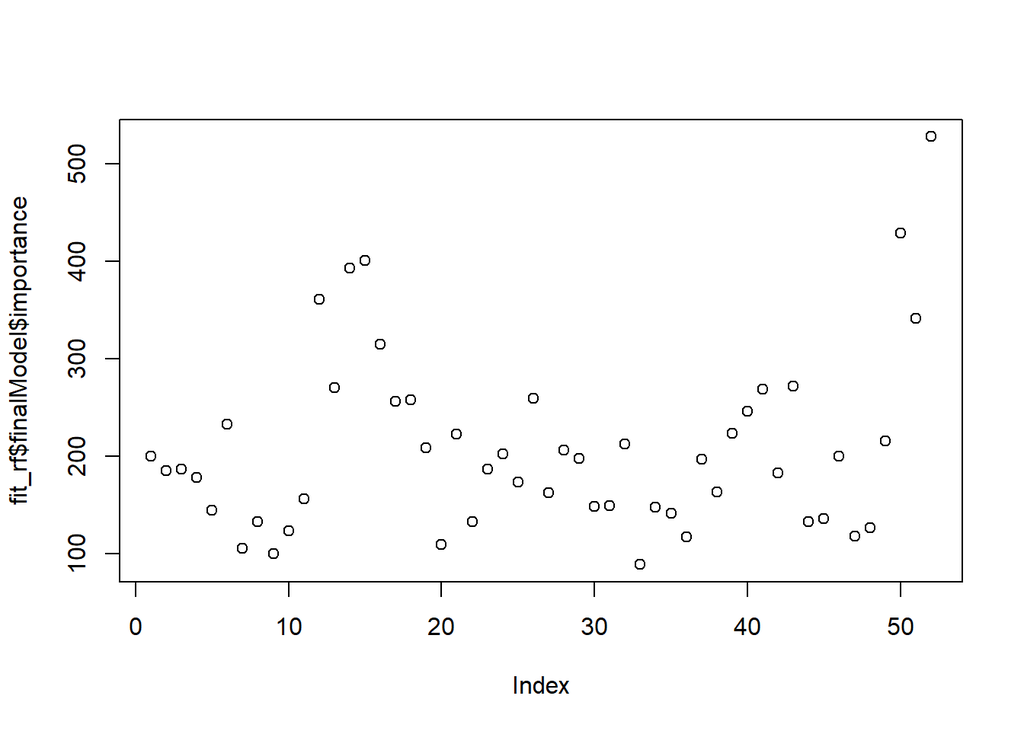

```r
plot(fit_rf$finalModel$importance)
```

## Model Testing

To test the model, we ran the chosen Random Forest model against the raw data. Due to space constraints, those figures are moved to Appendix 3.

```r
pred_key2 <- predict(fit_rf,newdata=key_raw2)
pred_key2_results <- data.frame(problem_id=key_raw2$problem_id,RFprediction=pred_key2)
```

## Conclusion

Given 160 variables to interpret, we were able to remove administrative entries, missing values, and near-zero-impact values. After narrowing to 52 predictors, we tried 3 models with 5-fold cross-validation, eventually choosing Random Forest. The RF approach had near-100% expected accuracy and under 1% out of sample error. Reviewing sample error is a suggested next step as well as gathering additional data on the NA dimensions.

# Appendices - Optional for graders’ convenience

## Appendix 1: Model results

```r
fit_dt
```

```
## CART
##
## 13737 samples
##    52 predictor
##     5 classes: 'A', 'B', 'C', 'D', 'E'
##
## No pre-processing
## Resampling: Cross-Validated (5 fold)
## Summary of sample sizes: 10990, 10991, 10988, 10990, 10989
## Resampling results across tuning parameters:
##
##   cp          Accuracy   Kappa
##   0.03549995  0.5137226  0.36996977
##   0.06092971  0.4167463  0.20952852
##   0.11738379  0.3326129  0.07373233
##
## Accuracy was used to select the optimal model using  the largest value.
## The final value used for the model was cp = 0.03549995.
```

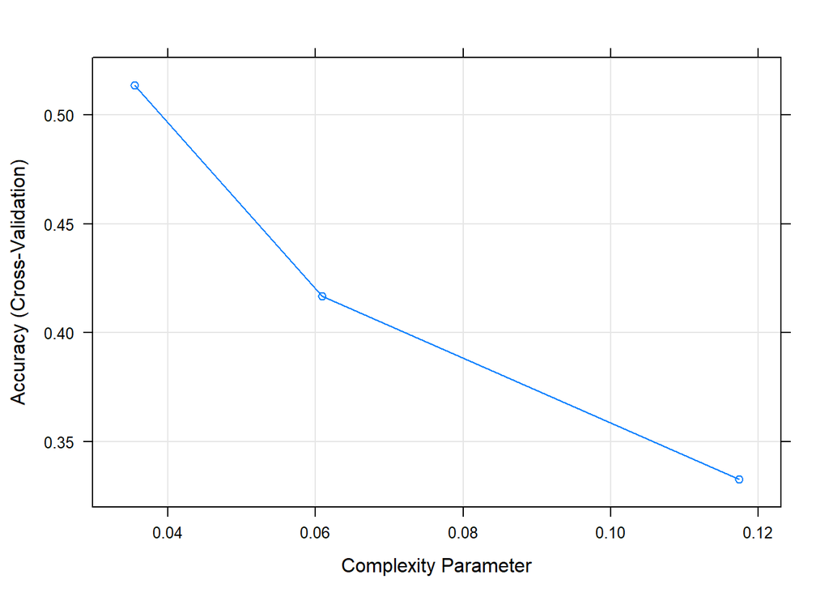

```r
plot(fit_dt)
```

```r
cm_dt
```

```
## Confusion Matrix and Statistics
##
##           Reference
## Prediction    A    B    C    D    E
##          A 1530  486  493  452  168
##          B   35  379   31  164  145
##          C  105  274  502  348  302
##          D    0    0    0    0    0
##          E    4    0    0    0  467
##
## Overall Statistics
##
##                Accuracy : 0.489
##                  95% CI : (0.4762, 0.5019)
##     No Information Rate : 0.2845
##     P-Value [Acc > NIR] : < 2.2e-16
##
##                   Kappa : 0.3311
##  Mcnemar's Test P-Value : NA
##
## Statistics by Class:
##
##                      Class: A Class: B Class: C Class: D Class: E
## Sensitivity            0.9140   0.3327   0.4893   0.0000  0.43161
## Specificity            0.6203   0.9210   0.7882   1.0000  0.99917
## Pos Pred Value         0.4890   0.5027   0.3279      NaN  0.99151
## Neg Pred Value         0.9478   0.8519   0.8797   0.8362  0.88641
## Prevalence             0.2845   0.1935   0.1743   0.1638  0.18386
## Detection Rate         0.2600   0.0644   0.0853   0.0000  0.07935
## Detection Prevalence   0.5317   0.1281   0.2602   0.0000  0.08003
## Balanced Accuracy      0.7671   0.6269   0.6388   0.5000  0.71539
```

```r
fit_rf
```

```
## Random Forest
##
## 13737 samples
##    52 predictor
##     5 classes: 'A', 'B', 'C', 'D', 'E'
##
## No pre-processing
## Resampling: Cross-Validated (5 fold)
## Summary of sample sizes: 10990, 10988, 10989, 10991, 10990
## Resampling results across tuning parameters:
##
##   mtry  Accuracy   Kappa
##    2    0.9904625  0.9879332
##   27    0.9903901  0.9878423
##   52    0.9869687  0.9835130
##
## Accuracy was used to select the optimal model using  the largest value.
## The final value used for the model was mtry = 2.
```

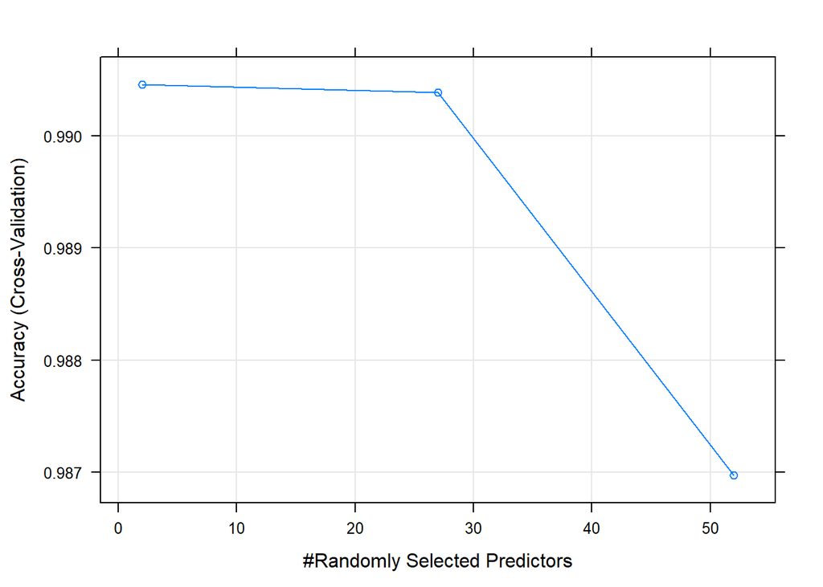

```r
plot(fit_rf)
```

```r
cm_rf
```

```
## Confusion Matrix and Statistics
##
##           Reference
## Prediction    A    B    C    D    E
##          A 1674    6    0    0    0
##          B    0 1131    7    0    0
##          C    0    2 1017   11    4
##          D    0    0    2  953    1
##          E    0    0    0    0 1077
##
## Overall Statistics
##
##                Accuracy : 0.9944
##                  95% CI : (0.9921, 0.9961)
##     No Information Rate : 0.2845
##     P-Value [Acc > NIR] : < 2.2e-16
##
##                   Kappa : 0.9929
##  Mcnemar's Test P-Value : NA
##
## Statistics by Class:
##
##                      Class: A Class: B Class: C Class: D Class: E
## Sensitivity            1.0000   0.9930   0.9912   0.9886   0.9954
## Specificity            0.9986   0.9985   0.9965   0.9994   1.0000
## Pos Pred Value         0.9964   0.9938   0.9836   0.9969   1.0000
## Neg Pred Value         1.0000   0.9983   0.9981   0.9978   0.9990
## Prevalence             0.2845   0.1935   0.1743   0.1638   0.1839
## Detection Rate         0.2845   0.1922   0.1728   0.1619   0.1830
## Detection Prevalence   0.2855   0.1934   0.1757   0.1624   0.1830
## Balanced Accuracy      0.9993   0.9958   0.9939   0.9940   0.9977
```

```r
fit_gb
```

```
## Stochastic Gradient Boosting
##
## 13737 samples
##    52 predictor
##     5 classes: 'A', 'B', 'C', 'D', 'E'
##
## No pre-processing
## Resampling: Cross-Validated (5 fold)
## Summary of sample sizes: 10989, 10988, 10991, 10990, 10990
## Resampling results across tuning parameters:
##
##   interaction.depth  n.trees  Accuracy   Kappa
##   1                   50      0.7512563  0.6847177
##   1                  100      0.8201210  0.7723591
##   1                  150      0.8525155  0.8134206
##   2                   50      0.8531704  0.8139764
##   2                  100      0.9040557  0.8785763
##   2                  150      0.9309894  0.9126813
##   3                   50      0.8945920  0.8665253
##   3                  100      0.9416903  0.9262186
##   3                  150      0.9614908  0.9512806
##
## Tuning parameter 'shrinkage' was held constant at a value of 0.1
##
## Tuning parameter 'n.minobsinnode' was held constant at a value of 10
## Accuracy was used to select the optimal model using  the largest value.
## The final values used for the model were n.trees = 150,
##  interaction.depth = 3, shrinkage = 0.1 and n.minobsinnode = 10.
```

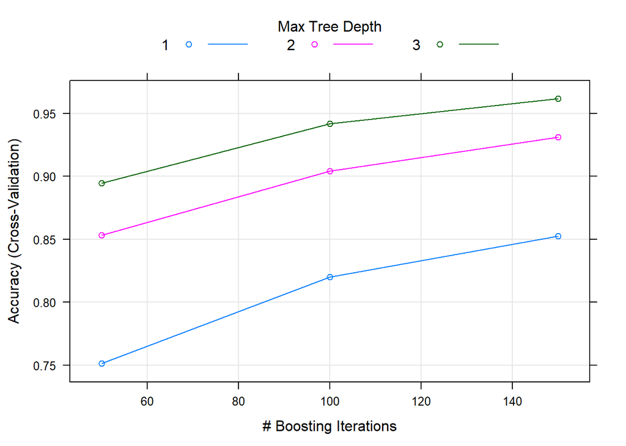

```r
plot(fit_gb)
```

```r
cm_gb
```

```
## Confusion Matrix and Statistics
##
##           Reference
## Prediction    A    B    C    D    E
##          A 1674    6    0    0    0
##          B    0 1131    7    0    0
##          C    0    2 1017   11    4
##          D    0    0    2  953    1
##          E    0    0    0    0 1077
##
## Overall Statistics
##
##                Accuracy : 0.9944
##                  95% CI : (0.9921, 0.9961)
##     No Information Rate : 0.2845
##     P-Value [Acc > NIR] : < 2.2e-16
##
##                   Kappa : 0.9929
##  Mcnemar's Test P-Value : NA
##
## Statistics by Class:
##
##                      Class: A Class: B Class: C Class: D Class: E
## Sensitivity            1.0000   0.9930   0.9912   0.9886   0.9954
## Specificity            0.9986   0.9985   0.9965   0.9994   1.0000
## Pos Pred Value         0.9964   0.9938   0.9836   0.9969   1.0000
## Neg Pred Value         1.0000   0.9983   0.9981   0.9978   0.9990
## Prevalence             0.2845   0.1935   0.1743   0.1638   0.1839
## Detection Rate         0.2845   0.1922   0.1728   0.1619   0.1830
## Detection Prevalence   0.2855   0.1934   0.1757   0.1624   0.1830
## Balanced Accuracy      0.9993   0.9958   0.9939   0.9940   0.9977
```

## Appendix 2: Exploration Results

Dimensions of the downloaded data (testing ‘key’ then training ‘example’) and a chart of NAs in each area (ex=example/training data, key = validation/testing data)

```r
dim(key_raw)
```

```
## [1]  20 160
```

```r
dim(example_raw)
```

```
## [1] 19622   160
```

```r
NAtable
```

```
##           FALSE TRUE
## ex_allna    154    6
## ex_anyna     60  100
## key_allna    60  100
## key_anyna    60  100
```

## Appendix 3: Final Test Results

Below are listed the final predictions of the chosen model against the raw testing ‘key’ data.

```r
pred_key2_results
```

```
##    problem_id RFprediction
## 1           1            B
## 2           2            A
## 3           3            B
## 4           4            A
## 5           5            A
## 6           6            E
## 7           7            D
## 8           8            B
## 9           9            A
## 10         10            A
## 11         11            B
## 12         12            C
## 13         13            B
## 14         14            A
## 15         15            E
## 16         16            E
## 17         17            A
## 18         18            B
## 19         19            B
## 20         20            B
```